# 政治学方法論Ⅰ : 課題6

金田 小絵子

2016年6月1日

```r
#load the package
library(ggplot2)
theme_set(theme_gray(base_size = 12, base_family = "HiraKakuProN-W3"))
```

## 問1

与えられたベクトルを昇順（デフォルト）に並べ替える関数`my_quicksort`を作る。 また、引数により降順にも並べ替えられるようにする。

```r
my_quicksort <- function(x, decreasing = FALSE){
    # ベクトルを並べ替えるための関数
    # 引数 : x = ベクトル
    #        decreasing = 降順で並び替える（デフォルトはFALSE = 昇順で並べ替える）
    # 返り値: vect = 並び替えられたベクトル

    # 長さ 1 以下のベクトルが入力された場合、そのベクトルをそのまま返す
    if (length(x) <= 1) return(x)


    # 長さ 2 以上のベクトルが入力されたとき
    # 軸要素を a として、x の中から 1 つランダムに決める
    a <- sample(x, 1)

    vect <- NULL
    vect <- ( c(my_quicksort(x[x < a]),
                # 軸 a より小さい x の要素でクイックソート
                x[x == a],
                # 軸 a と等しい x の要素でクイックソート
                my_quicksort(x[x > a])) )
                # 軸 a より大きい x の要素でクイックソート

    #decreasing（降順）が指定された場合は、ベクトルを逆順に並べ替える
    if(decreasing == TRUE) vect <- rev(vect)

    return(vect)
}
```

作成した関数 `my_quicksort` がきちんと動くか試す。

```r
# 最小値 -100 、最大値 100 の一様分布から 20 個の数字を無作為に選ぶ
( x <- runif(20, min = -100, max = 100) )
```

```
##  [1] -17.727693   1.574828 -92.163451 -76.711211 -92.548105 -49.704464
##  [7] -35.534701 -99.362042 -43.733634   1.296860  56.953871 -26.305672
## [13] -63.122875  28.458992  -6.626645  -9.228781  37.685617 -20.682527
## [19] -20.325963 -82.052781
```

```r
#Rの内臓関数と自作関数の結果を比較する
sort(x) == my_quicksort(x)
```

```
##  [1] TRUE TRUE TRUE TRUE TRUE TRUE TRUE TRUE TRUE TRUE TRUE TRUE TRUE TRUE
## [15] TRUE TRUE TRUE TRUE TRUE TRUE
```

## 問2

階乗を計算する関数`my_factorial`を作る。

```r
my_factorial <- function(n) {
    # 階乗を求める関数
    # arg: n = 非負の整数
    # return: fac = n!

    # 負値の入力に備える
    if (n < 0) stop(message = "n は非負です")

    # 小数の入力に備える
    if (n != round(n)) stop(message = "n は整数です")

    fac <- 1
    if (n > 0) { # n > 0 の場合のみ実行
      for (i in 1:n) {
        fac <- fac * i
      }
    }
    return(fac)
}
```

`factorial()`と作成した関数を比較し、`my_factorial`がきちんと動くか試す。

```r
factorial(10) == my_factorial(10)
```

```
## [1] TRUE
```

## 問3

`my_factorial`を用いて、組み合わせを計算する関数`my_choose`を作る。

```r
my_choose <- function(n, k){
    # 組み合わせを求める関数
    # 引数：n = 試行回数; 非負の整数
    #       k = 選んだ回数; k < n で非負の整数
    # 返り値：cho = n 回から k 回を選ぶ組み合わせ; 二項係数

    # k の負値の入力に備える
    if (k < 0) stop(message = "k は非負です")
    # k > nに備える
    if (k > n) stop(massage = "k は n 以下です")
    # k の小数の入力に備える
    if (k != round(k)) stop(massage = "k は整数です")

    cho <- my_factorial(n)/(my_factorial(k) * my_factorial(n - k))
    return(cho)
}
```

作成した関数`my_choose`がきちんと動くか試す。

```r
choose(10, 5) == my_choose(10, 5)
```

```
## [1] TRUE
```

## 問4

`my_choose`を用いて、二項分布の確率質量を求める関数`my_dbinom`を作成する。

```r
my_dbinom <- function(n, x, p){
    # 二項分布の確率質量を求める関数
    # 引数：n = ベルヌーイ試行の回数
    #       x = 成功回数
    #       p = ベルヌーイ試行における成功確率
    # 返り値：dbi = 二項分布の確率質量

    # pは確率なので、0 < p < 1
    if (p < 0 | p > 1) stop(message = " p は確率を表すため、0 < p < 1 です")

    dbi <- my_choose(n, x) * p^x * (1 - p)^(n - x)
    return(dbi)
}
```

作成した`my_dibinom`がきちんと動くか試す。

```r
dbinom(10, 3, .3) == my_dbinom(10, 3, .3)
```

```
## [1] FALSE
```

```r
my_dbinom(n = 10, x = 3, p = 0.3)
```

```
## [1] 0.2668279
```

```r
my_dbinom(10, 3, .3)
```

```
## [1] 0.2668279
```

## 問5

`my_dbinom`を用いて、 n が 2, 5, 10, 50 の場合について、確率質量を図示する。

そのために、`my_dbinom`を用いて、x が 0 から n まで変化するときの、それぞれの x における二項分布の確率質量を求め、データフレームを返す関数`get_df`を作成する。

```r
get_df <- function(n, p){
    #二項分布の確率質量のデータフレームを得る関数
    #引数：n = ベルヌーイ試行の回数
    #      p = ベルヌーイ試行における成功確率
    #返り値：xが0からnまで変化するときの
    #        確率質量PM=Probability Massを変数に持つデータフレーム

    #PMを格納するためのオブジェクトを作る
    pm <- NULL

    #xは0からnの値をとる整数である
    x <- 0:n

    for(i in 0:n){      #forループ #それぞれのiについてaを計算する
        a <- my_dbinom(n, i, p)
        pm <- append(pm, a)     #pmの中にそれぞれのiにおけるaを蓄積する
    }

    df <- data.frame(x = x, PM = pm)　  #変数 x とPM としてデータフレーム作成
    return(df)
}
```

次に、`ggplot2` で用いるデータフレームを作成するための関数を作る。 p の間隔(例えば 0.2 )を設定することで、間隔ごとにそれぞれの p （p = 0, 0.2, 0.4, 0.6, 0.8, 1）のときの x における確率質量を計算し、データフレームを返す変数を作成する。

```r
get_df2 <- function(n, interval = 0.2){
    # 成功確率 p が 0 から 1 を取るように、get_df を繰り返す関数
    # 引数 : n = ベルヌーイ試行の回数
    #        interval = p を求める間隔（デフォルトは0.1）
    # 返り値 : df = それぞれの p について get_df を繰り返した結果得られるデータフレーム

    # 図示の際に用いる、各試行に対応する p の値を表すベクトルを作成
    p <- rep(seq(0, 1, interval), (n + 1) )
    p <- my_quicksort(p)    # my_quicksort を用いて昇順に並べ変えておく

    # pの値を求め、その個数を求める
    p_num <- length(seq(0, 1, interval))

    #まず p = 0 の場合を計算し、データフレームを作る
    df <- get_df(n, 0)

    # get_df をそれぞれの p （> 0）に対して繰り返し、df に結果を蓄積する
    for(i in 1:(p_num - 1)){
        a <- get_df(n, 0.2*i )
        df <- rbind(df, a)
    }
    plotdf <- data.frame(x = df[,1], PM = df[,2], p = p)

}
```

この関数を用いてデータフレームを作成し、n = 2, 5, 10, 50 のそれぞれの場合を図示する。 以下の図では、p の値ごとに色分けを施している。

### n = 2

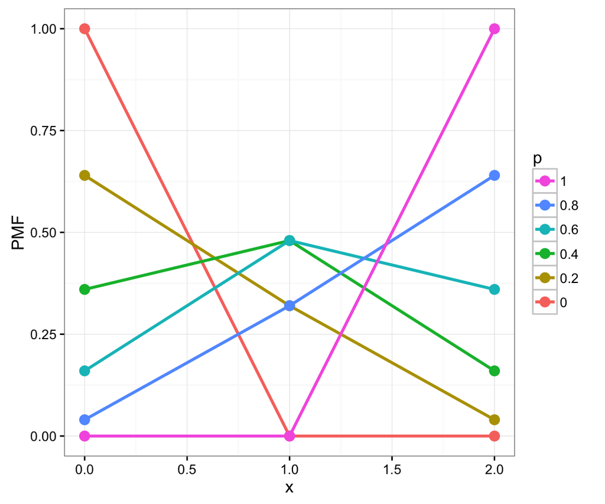

n = 2 のときの確率質量

```r
# get_df2 を用いてデータフレーム作成
df_n2 <- get_df2(n = 2, interval = 0.2)

# ggplots を用いて作図
plt_n2 <- ggplot(df_n2, aes(x = x, y = PM, label = factor(p), colour = factor(p))) +
    theme_bw() +
    guides(color = guide_legend(reverse = TRUE)) +
    geom_line(size = 1) +
    geom_point(size = 3) +
    labs(x = 'x', y = 'PMF', color = "p")
    print(plt_n2)
```

### n = 5

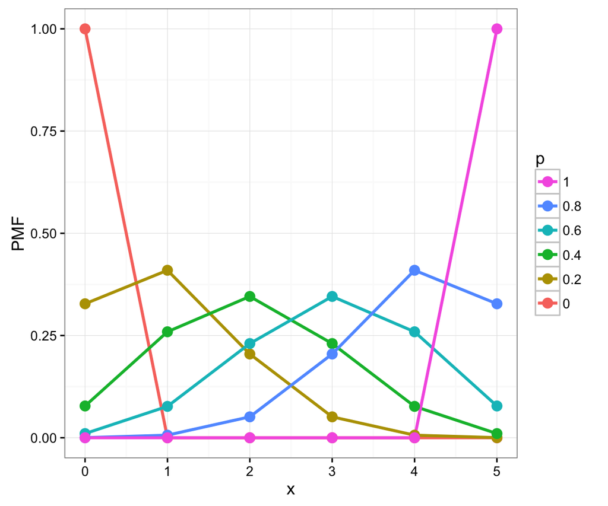

n = 5 のときの確率質量

```r
# get_df2 を用いてデータフレーム作成
df_n3 <- get_df2(n = 5, interval = 0.2)

# ggplots を用いて作図
plt_n3 <- ggplot(df_n3, aes(x = x, y = PM, label = factor(p), colour = factor(p))) +
    theme_bw() +
    guides(color = guide_legend(reverse = TRUE)) +
    geom_line(size = 1) +
    geom_point(size = 3) +
    labs(x = 'x', y = 'PMF', color = "p")
    print(plt_n3)
```

### n = 10

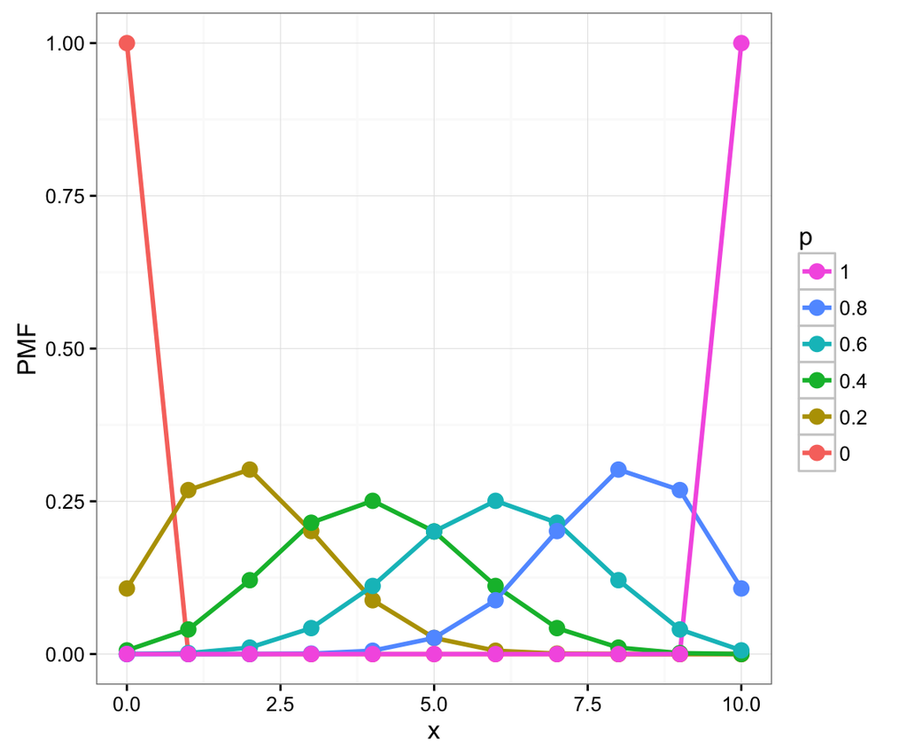

n = 10 のときの確率質量

```r
# get_df2 を用いてデータフレーム作成
df_n5 <- get_df2(n = 10, interval = 0.2)

# ggplots を用いて作図
plt_n5 <- ggplot(df_n5, aes(x = x, y = PM, label = factor(p), colour = factor(p))) +
    theme_bw() +
    guides(color = guide_legend(reverse = TRUE)) +
    geom_line(size = 1) +
    geom_point(size = 3) +
    labs(x = 'x', y = 'PMF', color = "p")
    print(plt_n5)
```

### n = 50

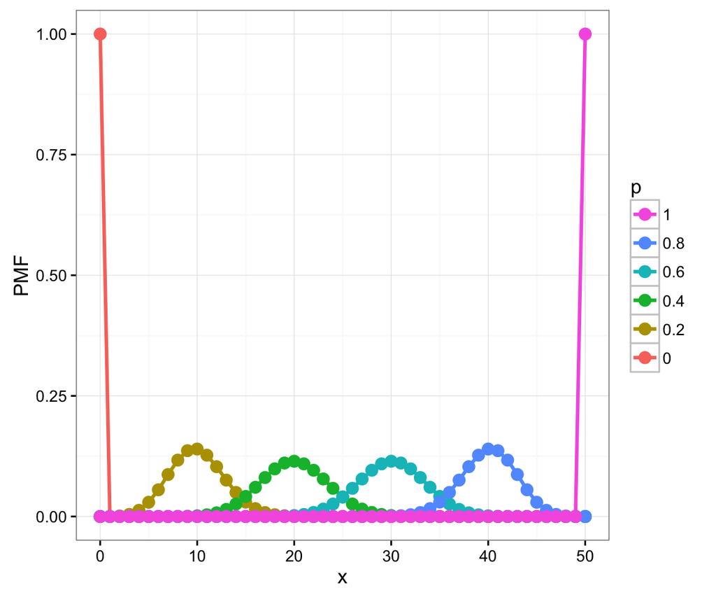

n = 50 のときの確率質量

```r
# get_df2 を用いてデータフレーム作成
df_n10 <- get_df2(n = 50, interval = 0.2)

# ggplots を用いて作図
plt_n10 <- ggplot(df_n10, aes(x = x, y = PM, label = factor(p), colour = factor(p))) +
    theme_bw() +
    guides(color = guide_legend(reverse = TRUE)) +
    geom_line(size = 1) +
    geom_point(size = 3) +
    labs(x = 'x', y = 'PMF', color = "p")
    print(plt_n10)
```